# Lab 09: Annotating Data Visualizations

## Pick a dataset

Today you’ll have a choice of three datasets to work with. You can choose either to investigate Donald Trump’s approval rating:

Murder rates across different cities in the US:

Pick a dataset (feel free to delete the others from the Rmd file if you would like), and work on the instructions in the next section.

## Instructions

Your goal in this lab is to construct an interesting visualization with the data that you choose above. You should make use of several manual annotations in an effort to tell a visual story about the dataset. Below, you should eventually provide a few sentences describing what you found in the dataset and then a single plot illustrating the interesting aspects of the data. You should incorporate some external information into your plot.

Note that you will certainly want to create many initial exploratory plots before settling on a final one for analysis. This time, make sure you that you upload both the Rmd and the html files to GitHub (remember, the final report should have just one single visualization).

Also note that you will have to use the format `x = as.Date("2017-01-06")` to add annotations to an axis that uses time as a component.

## Analysis

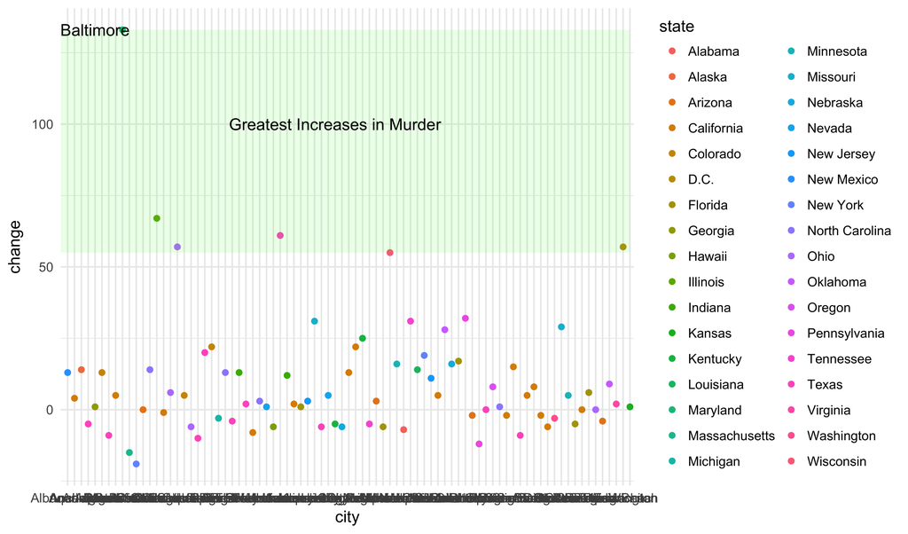

The cities of Baltimore, Milwaukee, Washington, Cleveland, Houston, Chicago are in in the top teir of increased murders making them some of the most dangerous cities. All of these cities are also located in different states, which can lead me to conlcude that state legislation must have little effect on murder rate. The city officials office may play a more vital role. I also found that of the cities provided in the data set a majority saw a spike in murders (53 of the 83). I also found that the greatest positive change 133 is more than the greatest negative -19. This data is not surprising as murder totals in the United States spiked from 14,164 in 2014 to 15,883 in 2015.